# D209 Data Mining

## Performance Assessment 2

### A1: Research Question

Can a model be created using lasso regression to predict the yearly bandwidth usage of a customer?

### A2: Goal of Analysis

The purpose of this analysis is to create a model that can accurately predict how much bandwidth a customer will use over the course of a year. This is useful because it can be used to identify if a new customer in an area could potentially cause network congestion and allow the company to take steps to mitigate service issues in that service area.

### B1: Justification for Classification Method

Lasso regression is a type of linear regression that uses regularization to improve the model. It uses the same linear formula as linear regression but introduces a penalty term to keep the coefficients from becoming too large. This prevents overfitting by preventing the model from over relying on the features with the largest coefficients. This penalty also has the effect of forcing some coefficients to zero making it a useful method for feature selection (Wohlwend, 2023). These traits should allow us to create an accurate generalized model to predict bandwidth usage.

### B2: Assumptions of Classification Method

Since lasso regression is a form of linear regression, the same assumptions for linear regression apply to lasso regression. The key assumption for linear regression is that a linear relationship exist between the independent and dependent variables. This means that as the value of the independent variable increases, the value of the dependent variable is assumed to increase or decrease along a straight line.

### B3: Packages for Analysis

##### Pandas

Pandas is a package used for creating and manipulating data frames.

##### Numpy

Numpy is a package used for mathematical operations on arrays.

##### Matplotlib

Matplotlib is a package used for creating visualizations in python.

##### SKLearn

Sklearn is a package used for machinge learning and statistical modeling.

###### Lasso

Lasso is a function in sklearn used to create lasso regression models.

###### Mean Squared Error

Mean Squared Error is a function in sklearn for calculating the mean squared error of residuals in a model.

###### Train Test Split

Train test split is a function for splitting data into training sets and testing sets.

###### KFold

Kfold is a function in sklearn used for performing cross validation.

###### Grid Search CV

Grid search cv is a function used to test and select the best hyperparameters for a model.

```python
import pandas as pd
import numpy as np
import matplotlib.pyplot as plt
from sklearn.linear_model import Lasso
from sklearn.metrics import mean_squared_error as MSE
from sklearn.model_selection import train_test_split, KFold, GridSearchCV
```

### C1: Preprocessing of Data

##### Variable Selection

The first step of preprocessing is to narrow down the number of variables used for the model. This will be done by creating an initial lasso model and plotting the coefficients for each variable on a bar chart. The variables with non-zero coefficients will be selected for the final analysis.

#### Dummy Variables

The next step will be to convert all of our categorical variables into numerical values by creating dummies for each one. This will be done using the get_dummies method.

### C2: Variables Used in Analysis

1. Children: Numerical
2. Age: Numerical
3. Tenure: Numerical
4. Gender: Categorical
5. Internet Service: Categorical
6. Multiple: Categorical
7. Online Security: Categorical
8. Online Backup: Categorical
9. Device Protection: Categorical
10. Tech Support: Categorical
11. Streaming TV: Categorical
12. Streaming Movies: Categorical

### C3: Preprocessing Steps

First we will read in our data and separate out our dependent variable and the variables to be considered for used as independent variables.

```python
# read in csv file
df = pd.read_csv('churn_clean.csv', na_values="NA", keep_default_na=False)
df.columns = df.columns.str.lower() # convert column names to all lower case
df.info()
```

```
<class 'pandas.core.frame.DataFrame'>
RangeIndex: 10000 entries, 0 to 9999
Data columns (total 50 columns):
 #   Column                Non-Null Count  Dtype
---  ------                --------------  -----
 0   caseorder             10000 non-null  int64
 1   customer_id           10000 non-null  object
 2   interaction           10000 non-null  object
 3   uid                   10000 non-null  object
 4   city                  10000 non-null  object
 5   state                 10000 non-null  object
 6   county                10000 non-null  object
 7   zip                   10000 non-null  int64
 8   lat                   10000 non-null  float64
 9   lng                   10000 non-null  float64
```

[output cut: 42 more lines]

```python
drop_var = ['caseorder', 'customer_id', 'interaction', 'uid', 'city', 'state', 'county', 'zip',
           'lat', 'lng', 'item1', 'item2', 'item3', 'item4', 'item5', 'item6', 'item7', 'item8',
           'bandwidth_gb_year', 'job', 'monthlycharge', 'churn'] # variables not considered for analysis
X_initial_nodummy = df.drop(columns=drop_var, axis=1)

# take our initial independent variables and create dummies for categorical variables
X_initial = pd.get_dummies(X_initial_nodummy, drop_first=True, dtype='int64')
X_initial.columns = X_initial.columns.str.replace(' ','_').str.replace('-','_').str.replace('(','').str.replace(')','').str.lower()

y = df['bandwidth_gb_year'].copy() # define dependent variable
```

Next, we create a lasso model and plot the the coefficients for variable selection.

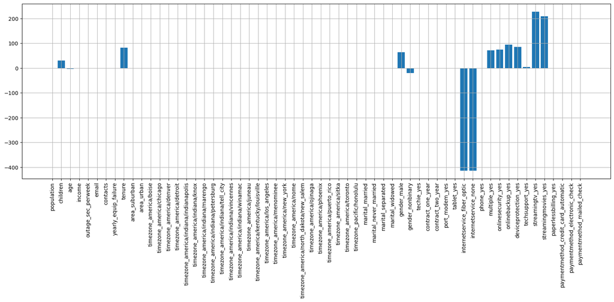

```python
var_names = X_initial.columns # used for labels on bar chart
lasso = Lasso(alpha=0.1)
lasso_coef = lasso.fit(X_initial, y).coef_
plt.figure(figsize=(20,6)) # resize plot for readability
plt.bar(var_names, lasso_coef)
plt.grid() # add grid overlay for readability
plt.xticks(rotation=90) # rotate the lables to make them easier to read
plt.show()
```

Finally, we save our final group of variables to X and create dummies for the categorical variables.

```python
X = df[['children', 'age', 'tenure', 'gender', 'internetservice', 'multiple', 'onlinesecurity', 'onlinebackup',
        'deviceprotection', 'techsupport', 'streamingtv', 'streamingmovies']].copy()
```

```python
X = pd.get_dummies(X, drop_first=True, dtype='int64')
X.columns = X.columns.str.replace(' ','_').str.replace('-','_').str.replace('(','').str.replace(')','').str.lower()
```

### C4: Cleaned Data Set

```python
# export final cleaned data set
# code commented out to prevent creating multiple copies
churn_final = pd.concat([X, y], axis=1)
#churn_final.to_csv(r'C:\Users\caleb\Documents\WGU\D209\churn_final_task2_jantsch.csv')
```

### D1: Creating Training and Testing Sets

```python
# split data into training and test sets
X_train, X_test, y_train, y_test = train_test_split(X, y, test_size=0.3, random_state=123)
```

```python
# export train and test sets
train_set = pd.concat([X_train, y_train], axis=1)
test_set = pd.concat([X_test, y_test], axis=1)
#train_set.to_csv(r'C:\Users\caleb\Documents\WGU\D209\train_set_task2_jantsch.csv')
#test_set.to_csv(r'C:\Users\caleb\Documents\WGU\D209\test_set_task2_jantsch.csv')
```

### D2: Description of Technique and Calculations

The technique used for this analysis is as follows. First, a cross validator is created using KFold. Then the lasso regressor is initialized. Then the cross validator and lasso regressor are passed to GridSearchCV to find the optimal value of alpha for the lasso regression. The model is fit to the training data. Finally, the best estimator is saved to best_lasso and the model evaluation metrics are calculated using our testing data.

### D3: Code

```python
kf = KFold(n_splits=6, random_state=123, shuffle=True) #cross validator using 6 folds
lasso = Lasso()
params = {'alpha': np.linspace(0.0001, 10, 50)} # parameters for hyperparameter tuning
lasso_cv = GridSearchCV(lasso, params, cv=kf)
lasso_cv.fit(X_train, y_train)
print(lasso_cv.best_params_)
print(lasso_cv.best_score_)
```

```
{'alpha': 0.0001}
0.9998486901336028
```

```python
best_lasso = lasso_cv.best_estimator_ #model containing best model from GridSearchCV
y_pred = best_lasso.predict(X_test) #predict y using testing data
rsq = best_lasso.score(X_test, y_test) # R-squared for model using test data
mse = MSE(y_test, y_pred) #calculate mean squared error
rmse = mse**(1/2) # root mean squared error
print('R-squared:', rsq)
print('Mean Squared Error:', mse)
print('Root Mean Squared Error:', rmse)
```

```
R-squared: 0.9998480462949543
Mean Squared Error: 719.2791154692511
Root Mean Squared Error: 26.81937947584267
```

```python
# print out summary statistics of y for discussion in next section
y.describe()
```

```
count    10000.000000
mean      3392.341550
std       2185.294852
min        155.506715
25%       1236.470827
50%       3279.536903
75%       5586.141370
max       7158.981530
Name: bandwidth_gb_year, dtype: float64
```

### E1: Accuracy and Mean Squared Error

#### Accuracy

The r-squared for this model 0.9998. This means that 99.98% of the variance in the data is explained by the model. This means that the model is an extremely good fit for the data and can be assumed to be very accurate.

#### Mean Squared Error

The mean squared error is a metric for evaluating the accuracy of a model. It is calculated by taking the mean of the sum of residuals squared. The lower the value the better. The mean squared error for this model is 719.28. However, it can be difficult to say whether this is a small value for the data. For this reason, it may be better to look at the root mean squared error for evaluating the model. The root mean squared error gives us the average difference between the predicted value and the actual value. The smaller the root mean squared error, the more precise your predictions are assumed to be. The root mean squared error for this model is 26.82. Considering that we are predicting values that are in the thousands, this can be considered to be a very good value for our model.

### E2: Discussion of Results

As shown in the previous section, the evaluation metrics of the model indicate that we have created a model that can predict the bandwidth usage of a customer with great accuracy. This means that the company will have the ability to estimate how much bandwidth a customer will use over the course of a year before they even begin their contract. If applied correctly, it could be highly useful for company operations moving forward.

### E3: Limitations

One of the key limitations of lasso regression is the selection of the regularization parameter (represented as alpha in the code above). If it is too big, important variables may be ignored. If it is too small, the model could overfit the data. This can be mitigated through trial and error or by using cross validation (Wohlwend, 2023).

### E3: Course of Action

Now that we have created our model, the next step would be to present it to the organization and determine how it could best be utilized in company operations.

### F: Panopto Recording

https://wgu.hosted.panopto.com/Panopto/Pages/Viewer.aspx?id=624fa181-5caf-41ff-b76c-b11c00f16263

### G: Code Sources

No code sources were used for this analysis.

### H: Text Sources

Wohlwend, B. (2023, July 14). *Three Regression Models for Data Science: Linear Regression, Lasso Regression, and Ridge Regression*. Medium. https://medium.com/@brandon93.w/three-regression-models-for-data-science-linear-regression-lasso-regression-and-ridge-regression-6aac73c0d7a5#:~:text=Bias%2DVariance%20Tradeoff%3A%20Linear%20Regression,to%20a%20better%20overall%20model.